# Estimating fitness costs of pyrethroid resistance in RLEM

James Maino

29/04/2020

Load and clean data.

```
## # A tibble: 6 x 18
##   date       location month time  weather plot  trtcode damage quadrat
##   <date>     <chr>    <chr> <chr> <chr>   <chr>   <dbl>  <dbl>   <int>
## 1 2017-06-26 Tintina~ June  11.2  foggy.~ A3          1      4       1
## 2 2017-06-26 Tintina~ June  12.95 foggy.~ C2          1      4       1
## 3 2017-06-26 Tintina~ June  13.65 foggy.~ D1          1      1       1
## 4 2017-06-26 Tintina~ June  14    foggy.~ D2          1      3       1
## 5 2017-06-26 Tintina~ June  15.4  foggy.~ E3          1      3       1
## 6 2017-06-27 Tintina~ June  10.9  cloudy  I1          1      3       1
## # ... with 9 more variables: kdr_insects.tested <int>, kdr_percent <dbl>,
## #   kdr_prop <dbl>, alleles_screened <dbl>, year <chr>, years <dbl>,
## #   year_month <chr>, days <dbl>, days_s <dbl>
```

Fit a logistic regression with random effects for repeated measured on plot. kdr proportion is the response variable weighted by the number of alleles screened (individual mites X2).

Full model includes fixed effect of time and location (with interaction) and random effect of plot.

```r
m0.0 = glmer(kdr_prop~  (1|plot),
            weights = alleles_screened, data=d, family = binomial)
m0.1 = glmer(kdr_prop~ location  + (1|plot),
            weights = alleles_screened, data=d, family = binomial)
m0.2 = glmer(kdr_prop~ location + days_s  + (1|plot),
            weights = alleles_screened, data=d, family = binomial)
m1 = glmer(kdr_prop~ location/days_s  + (1|plot), weights = alleles_screened,
          data=d, family = binomial)
d$pred_m1 = predict(m1, type= "response") # predictions with random effects
d$pred_fixed_m1 = predict(m1, type= "response", re.form=~0) # fixed effect only
anova(m0.0, m0.1, m0.2, m1)
```

```
## Data: d
## Models:
## m0.0: kdr_prop ~ (1 | plot)
## m0.1: kdr_prop ~ location + (1 | plot)
## m0.2: kdr_prop ~ location + days_s + (1 | plot)
## m1: kdr_prop ~ location/days_s + (1 | plot)
##      Df    AIC    BIC  logLik deviance   Chisq Chi Df Pr(>Chisq)
## m0.0  2 1719.4 1726.0 -857.69   1715.4
## m0.1  3 1660.5 1670.4 -827.26   1654.5 60.8642      1  6.115e-15 ***
## m0.2  4 1567.8 1581.0 -779.91   1559.8 94.7062      1  < 2.2e-16 ***
## m1    5 1568.0 1584.5 -779.02   1558.0  1.7773      1     0.1825
## ---
## Signif. codes:  0 '***' 0.001 '**' 0.01 '*' 0.05 '.' 0.1 ' ' 1
```

```r
summary(m1)
```

```
## Generalized linear mixed model fit by maximum likelihood (Laplace
##   Approximation) [glmerMod]
##  Family: binomial  ( logit )
## Formula: kdr_prop ~ location/days_s + (1 | plot)
##    Data: d
## Weights: alleles_screened
##
##      AIC      BIC   logLik deviance df.resid
##   1568.0   1584.5   -779.0   1558.0      192
##
## Scaled residuals:
##     Min      1Q  Median      3Q     Max
## -9.3108 -0.8978  0.1027  1.2571  5.2902
##
## Random effects:
##  Groups Name        Variance Std.Dev.
##  plot   (Intercept) 0.08237  0.287
## Number of obs: 197, groups:  plot, 24
##
## Fixed effects:
##                             Estimate Std. Error z value Pr(>|z|)
## (Intercept)                  1.64330    0.09136  17.986  < 2e-16 ***
## locationTintinara           -2.08982    0.12676 -16.486  < 2e-16 ***
## locationArthur River:days_s -0.25944    0.03832  -6.770 1.29e-11 ***
## locationTintinara:days_s    -0.19629    0.02771  -7.084 1.40e-12 ***
## ---
## Signif. codes:  0 '***' 0.001 '**' 0.01 '*' 0.05 '.' 0.1 ' ' 1
##
## Correlation of Fixed Effects:
##             (Intr) lctnTn lcAR:_
## locatnTntnr -0.721
## lctnARvr:d_ -0.111  0.080
## lctnTntnr:_ -0.001 -0.080 -0.002
```

Comparison of AIC scores and liklihood ratio tests, suggests an effect of time and location of resistance frequencies but no interation of location and decrease in resistance through time i.e. no evidence for different fitness costs by location.

We can calculate the confidence intervals for the rate of decrease for each location (on logit scale).

```r
confint(m1)
```

```
## Computing profile confidence intervals ...
```

```
##                                  2.5 %     97.5 %
## .sig01                       0.2104541  0.4053938
## (Intercept)                  1.4587167  1.8302401
## locationTintinara           -2.3493525 -1.8326237
## locationArthur River:days_s -0.3347008 -0.1842853
## locationTintinara:days_s    -0.2507065 -0.1420548
```

Summarise results across all replicates and plot means and standard error. See supplementary plot for individual replicates and random effects.

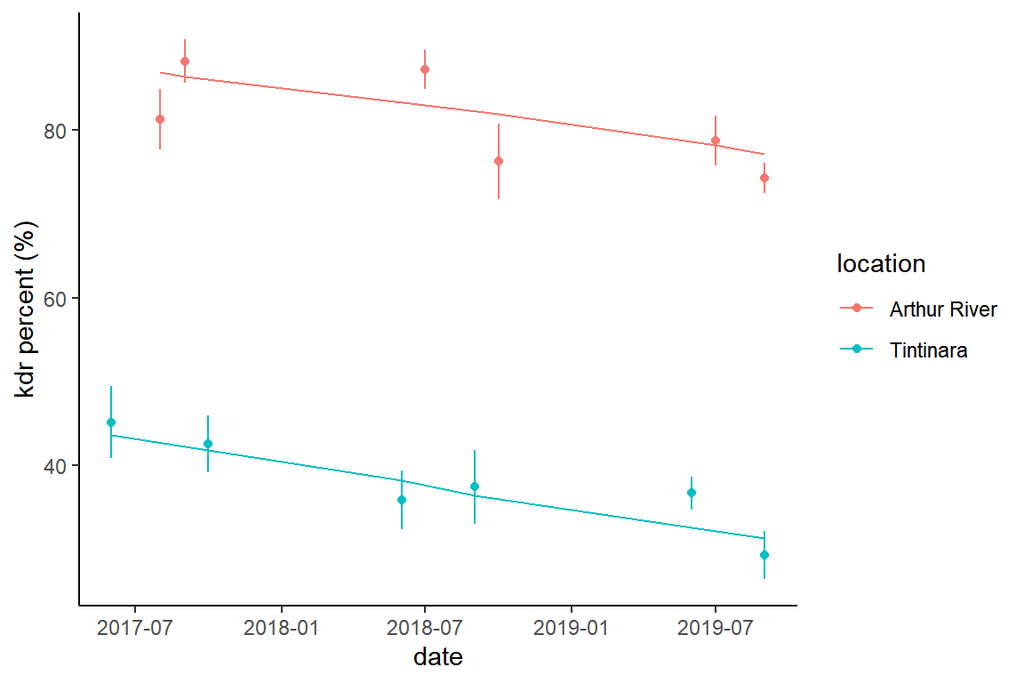

```r
dsum = d %>%
  group_by(year_month, location, trtcode) %>%
  summarise(
    days = mean(days),
    days_s = mean(days_s),
    kdr_se = sd(kdr_percent, na.rm=T)/sqrt(n()),
    kdr_percent = mean(kdr_percent, na.rm=T),
    n = n()
  )%>%
  mutate(rough_date = as.Date(paste0(year_month, '-01')))
dsum$pred_fixed_m1 =  predict(m1, type="response", re.form=~0, newdata = dsum)

p2 = ggplot(dsum, aes(x=rough_date, y=kdr_percent, colour=location)) +
  geom_point(aes()) +
  geom_line(aes(y=100*pred_fixed_m1, group = location)) +
  geom_errorbar(aes(ymin=kdr_percent-kdr_se, ymax=kdr_percent+kdr_se),
                width = 0.1) +
  xlab('date') +
  ylab('kdr percent (%)') +
  theme_classic()
p2
```

```r
ggsave(plot=p2, 'plots/kdr_summary.png')
```

From here we can fit a population genetics function for expected allele frequency through time. Using this function we can estimate the parameter for relative fitness of resistance genotypes. Starting resistance frequencies for the two locations are left as model parameters due to uncertainty in measurements.

First we need to convert sample time to generation number, assuming generation 1 was the first sample point.

```r
# assume first measure was generation 1
gens_per_year = 3  # assume 3 generations per year and linear development
diapause_days = 181  # assume no development from Nov-April

d = d %>%
  mutate(
    generation = 1 +
      round(
        gens_per_year * (days - years*diapause_days)/
          (365 - diapause_days)))  %>%
  group_by(location, plot) %>%
  mutate(initR = mean(kdr_prop[days <= 3], na.rm=T))
```

Next we need a function that can estimate resistance frequency given the starting resistance level, number of generations, dominance of fitness costs, and fitness costs.

```r
estimate_R_freq = function(w_RR, h = 0.5, generation, location, initR_A, initR_T){
  # w_RR: relative fitness of RR genotype
  #h: dominance
  w_SS = 1 # relative fitness of SS genotype
  w_RS = w_RR * h + (1 - h)*w_SS # relative fitness of RS genotype

  n = length(generation)
  p_out = numeric(n)
  for(i in 1:n) {
    p =  ifelse(location[i]=="Tintinara", initR_T, initR_A)# intial R frequency
    current_gen = 1
    while(current_gen < generation[i]){
      q = 1 - p # S frequency
      w_bar = p^2*(w_RR) + 2*p*q*(w_RS) + q^2*(w_SS) # mean fitness
      p = p^2 * w_RR / w_bar + p * q * w_RS / w_bar # update R frequency
      current_gen = current_gen + 1
    }
    p_out[i] = p
  }
  return(p_out)
}
estimate_R_freq(w_RR=0.7, h=0, generation=2,
                location="Tintinara", initR_A=0.9, initR_T=0.5)
```

```
## [1] 0.4594595
```

We can then leave fitness cost as a free parameter and estimate it from the data. I fit three models assuming fitness is recessive (h = 0), intermediate recessive (h = 0.5), and dominant (h = 1).

```r
m2_recessive =
  nls(kdr_prop~estimate_R_freq(w_RR, h=0, generation,  location, initR_A, initR_T),
        data=d, start=c(w_RR=0.5, initR_A=0.9, initR_T=0.5))
m2_intermediate =
  nls(kdr_prop~estimate_R_freq(w_RR, h=0.5, generation,  location, initR_A, initR_T),
        data=d, start=c(w_RR=0.5, initR_A=0.9, initR_T=0.5))
m2_dominant =
  nls(kdr_prop~estimate_R_freq(w_RR, h=1, generation,  location, initR_A, initR_T),
        data=d, start=c(w_RR=0.5, initR_A=0.9, initR_T=0.5))

calc_r2 = function(m){
  SS = sum((d$kdr_prop - mean(d$kdr_prop))^2)
  SSresid = sum(residuals(m)^2)
  r2 = 1 - SSresid/SS
  print(sprintf("r-squarred: %1.3f", r2))
}

summary(m2_recessive); calc_r2(m2_recessive)
```

```
##
## Formula: kdr_prop ~ estimate_R_freq(w_RR, h = 0, generation, location,
##     initR_A, initR_T)
##
## Parameters:
##         Estimate Std. Error t value Pr(>|t|)
## w_RR     0.89258    0.03740   23.86   <2e-16 ***
## initR_A  0.84992    0.01827   46.53   <2e-16 ***
## initR_T  0.42269    0.02417   17.49   <2e-16 ***
## ---
## Signif. codes:  0 '***' 0.001 '**' 0.01 '*' 0.05 '.' 0.1 ' ' 1
##
## Residual standard error: 0.1623 on 194 degrees of freedom
##
## Number of iterations to convergence: 4
## Achieved convergence tolerance: 8.771e-06
```

```
## [1] "r-squarred: 0.639"
```

```r
summary(m2_intermediate); calc_r2(m2_intermediate)
```

```
##
## Formula: kdr_prop ~ estimate_R_freq(w_RR, h = 0.5, generation, location,
##     initR_A, initR_T)
##
## Parameters:
##         Estimate Std. Error t value Pr(>|t|)
## w_RR     0.85741    0.04294   19.97   <2e-16 ***
## initR_A  0.84495    0.01640   51.53   <2e-16 ***
## initR_T  0.44728    0.02746   16.29   <2e-16 ***
## ---
## Signif. codes:  0 '***' 0.001 '**' 0.01 '*' 0.05 '.' 0.1 ' ' 1
##
## Residual standard error: 0.1615 on 194 degrees of freedom
##
## Number of iterations to convergence: 4
## Achieved convergence tolerance: 1.162e-06
```

```
## [1] "r-squarred: 0.642"
```

```r
summary(m2_dominant); calc_r2(m2_dominant)
```

```
##
## Formula: kdr_prop ~ estimate_R_freq(w_RR, h = 1, generation, location,
##     initR_A, initR_T)
##
## Parameters:
##         Estimate Std. Error t value Pr(>|t|)
## w_RR     0.85782    0.04552   18.84   <2e-16 ***
## initR_A  0.82644    0.01396   59.20   <2e-16 ***
## initR_T  0.46006    0.03095   14.86   <2e-16 ***
## ---
## Signif. codes:  0 '***' 0.001 '**' 0.01 '*' 0.05 '.' 0.1 ' ' 1
##
## Residual standard error: 0.1619 on 194 degrees of freedom
##
## Number of iterations to convergence: 4
## Achieved convergence tolerance: 8.644e-06
```

```
## [1] "r-squarred: 0.640"
```

Intermediate recessiveness marginally explains the most variance, but the models all perform similarly well. Interestingly, the estimated relative fitness of the RR genotype is fairly insensitive to dominance as shown in the above model summary outputs where relative fitness of RR varies from 0.86 to 0.89.

We can plot the the theoretical predictions against the data (under difference fitness dominace sceience).

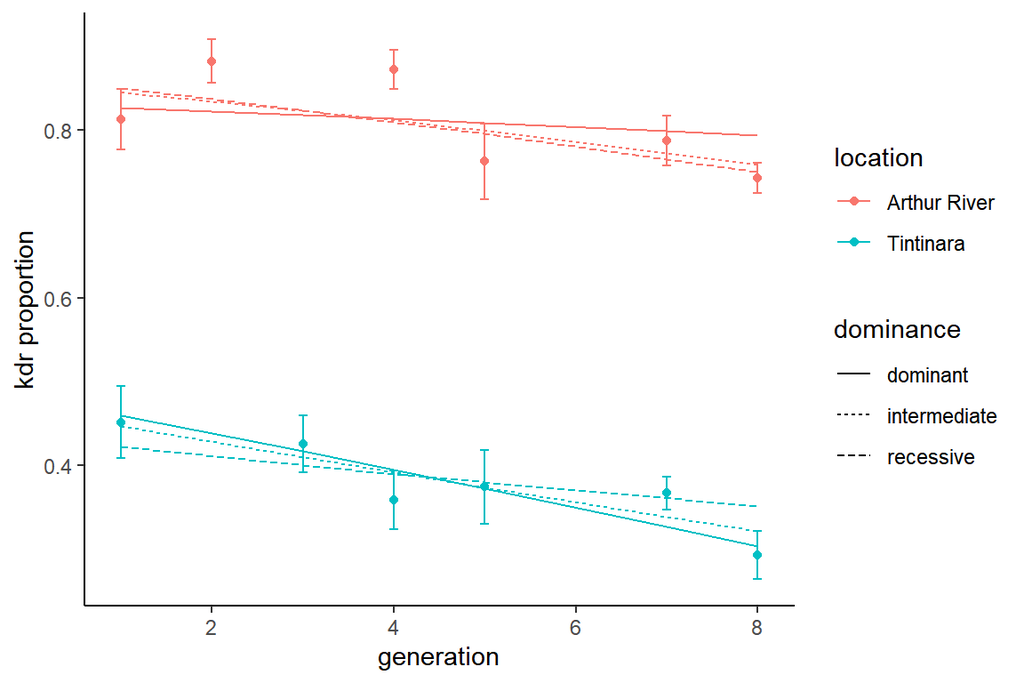

```r
d$pred_recessive = predict(m2_recessive)
d$pred_intermediate = predict(m2_intermediate)
d$pred_dominant = predict(m2_dominant)

dsum = d %>%
  group_by(generation, location, trtcode) %>%
  summarise(
    days = mean(days),
    days_s = mean(days_s),
    kdr_se = sd(kdr_prop, na.rm=T)/sqrt(n()),
    kdr_prop = mean(kdr_prop, na.rm=T),
    n = n()
  )

pred = d %>%
  ungroup %>%
  dplyr::select(generation, location, pred_recessive, pred_intermediate, pred_dominant) %>% distinct() %>%
  gather(dominance, kdr_prop, pred_recessive, pred_intermediate, pred_dominant) %>%
  mutate(dominance = gsub("pred_","", dominance))


p3 = ggplot(dsum, aes(x=generation, y=kdr_prop, colour=location)) +
  geom_point(aes()) +
  geom_errorbar(aes(ymin=kdr_prop-kdr_se, ymax=kdr_prop+kdr_se),
                width = 0.1) +
  geom_line(data = pred, aes(y=kdr_prop, color = location, linetype = dominance)) +
  xlab('generation') +
  ylab('kdr proportion') +
  theme_classic()
p3
```

```r
ggsave(plot=p2, 'plots/kdr_summary.png')
```

# Supplementary

We can plot kdr frequency for each replicate plot. Lines show predicted values for each plot while shapes show observed data. Size of shapes denote the number of alleles screened per sample.

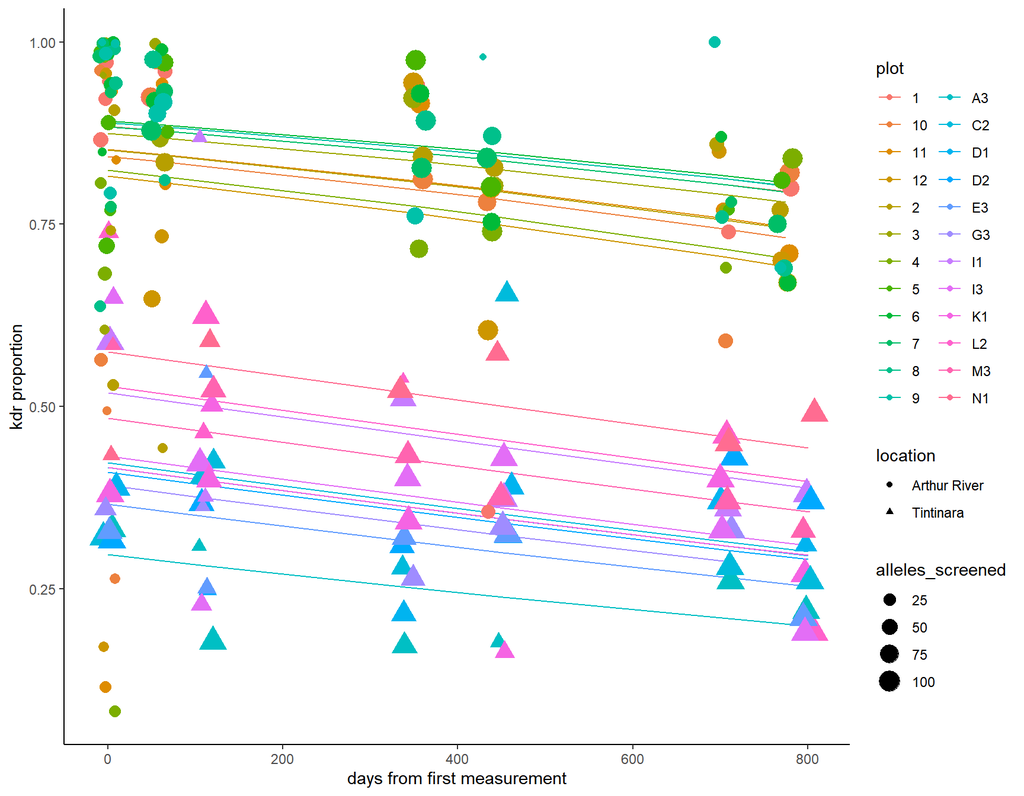

```r
p1 = ggplot(d,
       aes(x=days, colour=plot)) +
  # geom_text(aes(y=kdr_percent.mean, label = plot)) +
  geom_line(aes(y=pred_m1)) +
  # geom_line(aes(y=pred_fixed_m1, linetype = location), size =2, colour ='black') +
  geom_point(aes(y=kdr_percent/100, group = plot, size = alleles_screened, shape = location),
             position = position_jitter(width = 10)) +
  xlab('days from first measurement') +
  ylab('kdr proportion') +
  theme_classic()
p1
```

```r
ggsave(plot=p1, 'plots/full_model.png', height=7, width=9)
```